### Nome: Larissa de Oliveira Penteado

### NUsp: 8941338

```python
%matplotlib inline
import numpy as np
import matplotlib.pyplot as plt
import tensorflow as tf
```

# MAC0460/5832 - Lista 3: Redes Neurais - MNIST

### Data de Entrega: 23h55m do dia 23/06/2017

##### Classificação de dígitos

Os dataset para esta tarefa foi tirado da competição do kaggle de reconhecimento de dígitos (https://www.kaggle.com/c/digit-recognizer) e está disponível em http://vision.ime.usp.br/~caiomr/mac0460_5832/train.csv.gz. O dataset está sob a licença Creative Commons Attribution-Share Alike 3.0 license (https://creativecommons.org/licenses/by-sa/3.0/). O dataset foi zipado, mas os dados estão inalterados. Cada linha (amostra) do arquivo contém 785 colunas: a primeira informa o label da amostra e as outras 784 são os valores dos pixels da imagem (28 x 28) que representa o dígito.

Q1. Projete uma rede neural para resolver o problema de classificação de dígitos. Baixe o arquivo train.csv.gz (link acima) e dezipe-o para a pasta data/. Verifique que as células abaixo executam com sucesso e exibem o resultado esperado. Utilize os pacotes de python tensorflow (https://www.tensorflow.org/) ou theano (http://deeplearning.net/software/theano/) para implementar sua rede neural. Escolha o que preferir/tiver mais familiaridade - ou o quiser passar a ter mais familiaridade :) - para definir sua rede neural. Usem a arquitetura 3-layer NN 300+100 hidden units (erro 3.05%), como descrito no site http://yann.lecun.com/exdb/mnist/index.html.

Façam os três seguintes experimentos:

1. Imagem original.
2. Imagem amostrada com passo 1, isto é, reduz a imagem para 1/4 do número total de pixels.
3. Imagem amostrada com passo 2, isto é, reduz a imagem para 1/16 do número total de pixels.

Em cada experimento, execute os seguintes procedimentos:

1. Compute a curva experimental de aprendizado (N = 5000, N = 10000, N = 15000, ... N = 35000), estimar o $E_{out}$ a partir das 7000 amostras não usadas.
2. Para N = 35000 (isto é, separe 7000 amostras para validação), calcule o valor da precisão $\epsilon = E_{out} - E_{in}$.
3. Adote o valor de $\epsilon$ calculado em 2; repita dez vezes o experimento de aprendizado para $N = 35000$ e 7000 amostras de validação (em cada experimento, escolha aleatoriamente entre as 42000 amostras 7000 para formar o conjunto de validação e as restantes para treinamento); calcule o $E_{out}$ para cada um dos experimentos; a partir dos $E_{out}$ calculados, estime o valor do parâmetro $\delta$.
4. Comente os resultados obtidos.

Adote *learning rate* $\eta = 0.001$. Para o item 3, lembre da equação $P(|E_{out}(h_{opt}) - E_{in}(h_{opt})| < \epsilon) > 1 - \delta$.

```python
data = np.genfromtxt('data/train.csv', delimiter=',', skip_header=1).astype(np.dtype('uint8'))
print(data.shape)
```

```
(42000, 785)
```

```
Label:  1
```

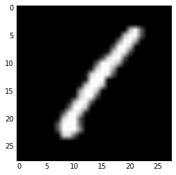

```
Label:  0
```

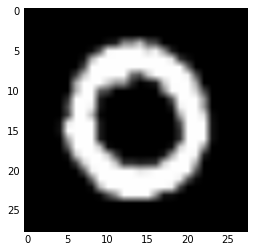

```
Label:  8
```

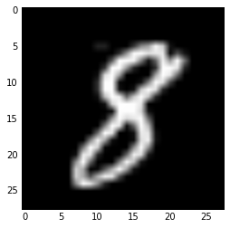

```python
sample = data[0]
print("Label: ", sample[0])
plt.imshow(sample[1:].reshape((28,28)), cmap='gray')
plt.show()

sample = data[1]
print("Label: ", sample[0])
plt.imshow(sample[1:].reshape((28,28)), cmap='gray')
plt.show()

sample = data[20]
print("Label: ", sample[0])
plt.imshow(sample[1:].reshape((28,28)), cmap='gray')
plt.show()
```

```python
input_size = 784
label_size = 10
layer1_size = 300
layer2_size = 100
learning_rate = 0.001
batch_size = 100
training_size = 35000
display = 5000
```

```python
labels_t = np.zeros((data.shape[0], 10))
labels_t[np.arange(data.shape[0]), data[:, 0].flatten()] = 1
```

```python
def model(input1, input_size, label_size, layer1_size, layer2_size):
    W0 = tf.Variable(tf.truncated_normal([input_size,layer1_size], stddev=0.1))
    b0 = tf.Variable(tf.truncated_normal([layer1_size], stddev=0.1))
    W1 = tf.Variable(tf.truncated_normal([layer1_size, layer2_size], stddev=0.1))
    b1 = tf.Variable(tf.truncated_normal([layer2_size], stddev=0.1))
    W2 = tf.Variable(tf.truncated_normal([layer2_size, label_size], stddev=0.1))
    b2 = tf.Variable(tf.truncated_normal([label_size], stddev=0.1))

    layer1 = tf.add(tf.matmul(input1, W0), b0)
    layer1 = tf.nn.relu(layer1)
    layer2 = tf.add(tf.matmul(layer1, W1), b1)
    layer2 = tf.nn.relu(layer2)

    output = tf.matmul(layer2, W2) + b2
    return output
```

```python
def perceptron(input_size, label_size, layer1_size, layer2_size, learning_rate, batch_size, training_size, display, random, data):

    input1 = tf.placeholder(tf.float32, shape=[None, input_size])
    label = tf.placeholder(tf.float32, shape=[None, label_size])

    apply_model = model(input1, input_size, label_size, layer1_size, layer2_size)
    cost = tf.reduce_mean(tf.nn.softmax_cross_entropy_with_logits(logits=apply_model, labels=label))
    optimizer = tf.train.AdamOptimizer(learning_rate=learning_rate).minimize(cost)
    correct_prediction = tf.equal(tf.argmax(apply_model, 1), tf.argmax(label, 1))
    accuracy = tf.reduce_mean(tf.cast(correct_prediction, tf.float32))

    n_batches = training_size//batch_size
    data_in = np.copy(data)
    if random == True:
        np.random.shuffle(data_in)
    labels_t = np.zeros((data_in.shape[0], 10))
    labels_t[np.arange(data_in.shape[0]), data_in[:, 0].flatten()] = 1
    in_err = []
    out_err = []
    init = tf.global_variables_initializer()

    with tf.Session() as sess:
        sess.run(init)

        for i in range(n_batches):
            _, c = sess.run([optimizer, cost], feed_dict={input1: data_in[i*batch_size:(i + 1)*batch_size, 1:],
                                                              label: labels_t[i*batch_size:(i + 1)*batch_size, :]})
            if (i*batch_size)%display == 0:
                correct_input = sess.run(accuracy, feed_dict={input1: data_in[:training_size, 1:],
                                                              label: labels_t[:training_size, :]})
                correct_val = sess.run(accuracy, feed_dict={input1: data_in[training_size:, 1:],
                                                              label: labels_t[training_size:, :]})

                in_err.append(1.0 - correct_input)
                out_err.append(1.0 - correct_val)
    return in_err, out_err
```

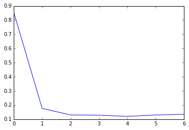

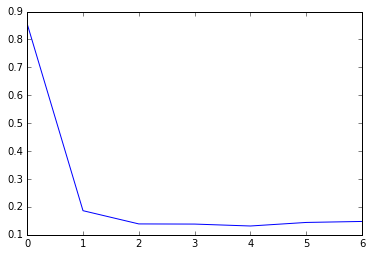

```python
ein, eout = perceptron(input_size, label_size, layer1_size, layer2_size, learning_rate, batch_size, training_size,
           display, False, data)

plt.plot(ein)
plt.show()
plt.plot(eout)
plt.show()

epsilon = np.abs(ein[-1] - eout[-1])
```

```python
p_1 = 0
for i in range(10):
    ein, eout = perceptron(input_size, label_size, layer1_size, layer2_size, learning_rate, batch_size, training_size,
           display, True, data)
    if np.abs(ein[-1]-eout[-1]) >= epsilon:
        p_1 +=1
delta = p_1/10.0
print("Delta dos experimentos com todos os pixels:", delta)
```

```
Delta dos experimentos com todos os pixeis: 0.8
```

```python
def get_data(data, step):
    data2 = []
    for i in range(data.shape[0]):
        data2_aux = data[i][1:].reshape((28, 28))
        data2_aux = data2_aux[::step,::step]
        data2.append(np.concatenate((np.array([data[i][0]]), np.asarray(data2_aux).reshape(-1))))
    data2 = np.asarray(data2)
    return data2
```

```python
input_size2 = 784//4
data2 = get_data(data, 2)
```

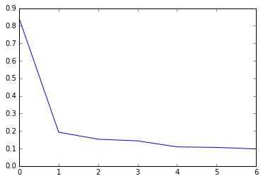

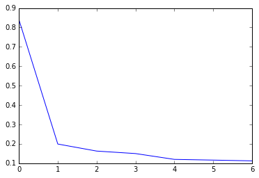

```python
ein, eout = perceptron(input_size2, label_size, layer1_size, layer2_size, learning_rate, batch_size, training_size,
           display, False, data2)

epsilon = np.abs(ein[-1] - eout[-1])

plt.plot(ein)
plt.show()
plt.plot(eout)
plt.show()
```

```python
p_2 = 0
for i in range(10):
    ein, eout = perceptron(input_size2, label_size, layer1_size, layer2_size, learning_rate, batch_size, training_size,
           display, True, data2)
    if np.abs(ein[-1]-eout[-1]) >= epsilon:
        p_2 +=1
delta = p_2/10.0
print("Delta dos experimentos com 1/4 os pixels:", delta)
```

```
Delta dos experimentos com 1/4 os pixeis: 0.4
```

```python
input_size3 = 784//16
data3 = get_data(data, 4)
```

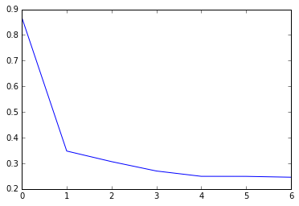

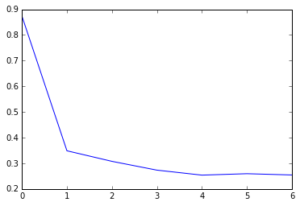

```python
ein, eout = perceptron(input_size3, label_size, layer1_size, layer2_size, learning_rate, batch_size, training_size,
           display, False, data3)

epsilon = np.abs(ein[-1]-eout[-1])
plt.plot(ein)
plt.show()
plt.plot(eout)
plt.show()
```

```python
p_3 = 0
for i in range(10):
    ein, eout = perceptron(input_size3, label_size, layer1_size, layer2_size, learning_rate, batch_size, training_size,
           display, True, data3)
    if np.abs(ein[-1]-eout[-1]) >= epsilon:
        p_3 +=1
delta = p_3/10.0
print("Delta dos experimentos com 1/16 os pixels:", delta)
```

```
Delta dos experimentos com 1/16 os pixeis: 1.0
```

### Comentários:

Para estimar o delta foi usado que: P(A < b) = 1 - P(A >= b), assim é natural que P(|eout - ein| >= epsilon) = delta

Além disso, 10 mostrou-se uma quantidade pequena para estimar o delta, uma vez que ele por vezes estimou delta como sendo 1. Ou seja, uma estimação grosseira. Se o número de vezes fosse maior, poderíamos ter uma estimação mais precisa. Outra modificação que poderia ajudar seria estimar o epsilon com base em mais execuções dos testes também, ao invés de uma única.

Q2. O método de aprendizado adotado na questão anterior inclui regularização? Caso afirmativo, como? Caso negativo, como formularia a inclusão da regularização e porque esse procedimento melhoraria o resultado?

Resposta: O método utilizado não inclui regularização. Para incluir regularização poderíamos utilizar o método de decaimento de pesos ou "weight decay". Com isso é possível evitar que ruídos ou overfitting tornem o classificador enviesado e ineficaz. O conjunto de funções de hipótese (H) se torna mais restrito e menos volátil às variações nos dados de entrada. Para implementá-lo, utilizamos a heurística de Erro Aumentado. E_aug = E_in + penalty_factor onde penalty_factor = lambda * w'w Isto força o algoritmo de learning a escolher entre fazer o erro de entrada (e_in) muito pequeno e fazer os pesos muito pequenos. Como queremos minimizar o erro aumentado, isto força que pesos muito grandes sejam evitados.

Como implementar utilizando o tensorflow:

.... def model (): .... W0 = tf.Variable(tf.truncated_normal([input_size,layer1_size], stddev=0.1))

```
with tf.variable_scope('W0') as scope:
    W0_norm = tf.reduce_sum(
             input_tensor = WEIGHT_DECAY_FACTOR*tf.pack(
             [tf.nn.l2_loss(i) for i in tf.get_collection('W0')]
             ),
    name='W0_norm')

tf.add_to_collection('losses', W0_norm)
tf.add_n(tf.get_collection('losses'), name='total_loss')
```